# HS Revision Stability & NAICS Concordance

How CVCE handles HS2017 vs HS2022 differences — methodology brief

Author

Affiliation

Oriol Vallès Codina

Net Zero Industrial Policy Lab, Johns Hopkins University

Published

April 13, 2026

## Executive Summary

**Tip**

The concordance chain is:

```
Green Dictionary (HS 6-digit) → NACE Rev.2 (4-digit) → NAICS 2017 (6-digit)
         ↕                              ↕                         ↕
    Trade data (BACI)              ORBIS firms             Compustat / S&P CIQ
```

**Why HS revision changes do not propagate to NACE/NAICS errors:**

1. NACE Rev.2 is fixed by EU Regulation EC 1893/2006 (effective 2008). No HS revision has changed it.
2. The HS→NACE mapping uses Eurostat’s CN–CPA–NACE correspondence tables, which translate *product concepts* not *code strings*. When HS creates a new code for a product concept that already had a NACE anchor, the new code gets the same anchor.
3. All 11 HS22 codes in the Green Dictionary that have no HS17 equivalent are *successors* of existing HS17 codes — they were created by splitting one code into more specific ones. The product concept (and therefore the NACE mapping) is unchanged.

## 1. The Concordance Chain

### 1.1 Three layers from trade codes to firm databases

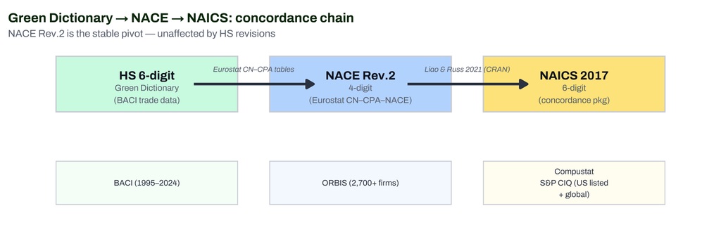

The three-layer concordance chain from HS trade codes to firm-level databases.

### 1.2 Why NACE is the stable pivot

NACE Rev.2 is governed by **EU Regulation EC 1893/2006** (in force since 1 January 2008). It is a classification of *economic activities*, not products. HS revisions reorganise *product descriptions* — they do not create or modify economic activity categories. As a result:

The HS revision therefore **does not cascade into a NACE or NAICS error**.

## 2. HS2017 vs HS2022: What Changed in the Green Dictionary

### 2.1 Scale of changes

Scale of HS2017→HS2022 changes affecting the Green Dictionary

| Metric | Count | Notes |
| --- | --- | --- |
| Total HS17→HS22 concordance edges | 790 | All WCO-published crosswalk edges |
| Of which 1-to-1 (simple renames) | 100 | Code changed, same product concept |
| Of which 1-to-n (splits) | 690 | One HS17 code → multiple HS22 codes |
| Green Dict HS17 codes that split in HS22 | 28 | 28 unique HS17 codes; 106 concordance edges |
| New HS22 Green Dict codes (no HS17 identity) | 11 | 11 codes; all have confirmed NACE4 + NAICS6 |
| Green Dict codes in HS22 canonical revision | 59 | 59 codes use HS22 as their canonical revision |

### 2.2 The 11 new HS22 codes: ancestry and NACE/NAICS coverage

These 11 codes appear in HS2022 but did not exist as independent codes in HS2017. Each was created by splitting an existing HS17 code — meaning the **same product** traded under a single code before 2022 now trades under a more specific one.

New HS22 codes in the Green Dictionary — ancestry and coverage

| Tech | HS22 Code | Product | Role | Stage | HS17 Predecessor(s) | NACE4 | NAICS6 |
| --- | --- | --- | --- | --- | --- | --- | --- |
| Batteries | 846223 | Electrode Production; Slitting to Width | Process Equipment | Downstream | 846221 | ✓ 2841 | ✓ 333517 |
| Electrolyzers | 846261 | Diffusion Layer Production; Metal Compaction | Process Equipment | Downstream | 846210, 846221, 846229, 846231, 846239, 846241, 846249, 846291 | ✓ 2841 | ✓ 333517 |
| Solar | 850171 | Photovoltaic DC Generators Under 50 MW | Product Component | Downstream | 850131 | ✓ 2711 | ✓ 335312 |
| Solar | 850172 | Photovoltaic DC generators over 50 MW | Product Component | Downstream | 850131, 850132, 850133, 850134 | ✓ 2711 | ✓ 335312 |
| Solar | 850180 | Photovoltaic AC Generators | Product Component | Downstream | 850161, 850162, 850163, 850164 | ✓ 2711 | ✓ 335312 |
| Solar | 851432 | Polysilicon Production; Electric Arc Furnace | Process Equipment | Midstream | 851430 | ✓ 2821 | ✓ 333994 |
| Solar | 854142 | Solar Cells | Product Component | Downstream | 854140 | ✓ 2611 | ✓ 334413 |
| Solar | 854143 | Modules (Assembled into Panels) | Final Product | Final Product | 854140 | ✓ 2611 | ✓ 334413 |
| Solar | 854149 | Solar Tracker; CDS Sensor | Product Component | Midstream | 854140 | ✓ 2611 | ✓ 334413 |
| Wind | 681511 | Rotor; Materials for Use in Rotor (Carbon Fibre) | Processed Material | Midstream | 681599 | ✓ 2399 | ✓ 327999 |
| Wind | 846224 | Tower Production: Plate Rolling Machine | Process Equipment | Downstream | 846221 | ✓ 2841 | ✓ 333517 |

**Note**

### 2.3 Worked example: Solar 854140 → 854142 / 854143 / 854149

This is the highest-profile split in our Green Dictionary:

| HS2017 Code | HS2017 Description | → HS2022 Split |
| --- | --- | --- |
| **854140** | Photosensitive semiconductor devices | **854142** Solar Cells (not assembled) |
|  |  | **854143** Solar Modules (assembled panels) |
|  |  | **854149** Other photosensitive devices (trackers, sensors) |

All three HS22 successors map to: - **NACE 2611** — Manufacture of electronic components and boards - **NAICS 334413** — Semiconductor and Related Device Manufacturing

The split provides *additional analytical precision* (we can now distinguish cells from modules in trade data) while leaving the firm-level classification unchanged.

## 3. Coverage by Technology

Green Dictionary NACE4 and NAICS6 coverage by technology

| Technology | Total HS codes | With NACE4 | % NACE | With NAICS6 | % NAICS | Final Products (NAICS) |
| --- | --- | --- | --- | --- | --- | --- |
| Batteries | 70 | 67 | 96 | 67 | 96 | 2/2 |
| Biofuel | 67 | 64 | 96 | 64 | 96 | 2/2 |
| Electrolyzers | 50 | 47 | 94 | 47 | 94 | 1/1 |
| Geothermal | 76 | 71 | 93 | 71 | 93 | 8/8 |
| Heat Pumps | 27 | 24 | 89 | 24 | 89 | 2/2 |
| Magnets | 20 | 20 | 100 | 20 | 100 | 2/2 |
| Nuclear | 41 | 39 | 95 | 39 | 95 | 2/2 |
| Solar | 51 | 50 | 98 | 50 | 98 | 2/2 |
| Transmission | 28 | 26 | 93 | 26 | 93 | 4/4 |
| Wind | 91 | 89 | 98 | 89 | 98 | 1/1 |

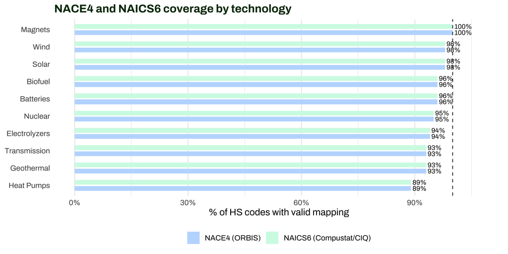

## 4. Known Gaps: Nature and Scope

### 4.1 Where coverage falls short of 100%

| Technology | Role | Stage | HS Chapter | # Codes | HS codes |
| --- | --- | --- | --- | --- | --- |
| Batteries | Process Equipment | Downstream | 90 | 1 | 902780 |
| Batteries | Processed Material | Midstream | 39 | 1 | 390760 |
| Batteries | Product Component | Midstream | 38 | 1 | 382490 |
| Biofuel | Process Equipment | Downstream | 84 | 1 | 840619 |
| Biofuel | Processed Material | Midstream | 29 | 1 | 293290 |
| Biofuel | Processed Material | Midstream | 68 | 1 | 681510 |
| Electrolyzers | Process Equipment | Downstream | 84 | 1 | 846241 |
| Electrolyzers | Process Equipment | Downstream | 85 | 2 | 851430, 854380 |
| Geothermal | Process Equipment | Downstream | 84 | 3 | 845610, 846021, 846210 |
| Geothermal | Process Equipment | Downstream | 85 | 1 | 851430 |
| Geothermal | Product Component | Downstream | 73 | 1 | 730420 |
| Geothermal | Process Equipment | Midstream | 84 | 1 | 846021 |
| Heat Pumps | Process Equipment | Downstream | 84 | 1 | 846241 |
| Heat Pumps | Processed Material | Midstream | 74 | 1 | 740110 |
| Heat Pumps | Product Component | Midstream | 25 | 1 | 252921 |
| Nuclear | Processed Material | Midstream | 28 | 1 | 282611 |
| Nuclear | Processed Material | Midstream | 81 | 1 | 810990 |
| Solar | Product Component | Downstream | 85 | 1 | 854140 |
| Transmission | Process Equipment | Downstream | 84 | 1 | 846241 |
| Transmission | Processed Material | Midstream | 74 | 1 | 740110 |
| Wind | Process Equipment | Midstream | 84 | 1 | 846221 |
| Wind | Processed Material | Midstream | 74 | 1 | 740110 |

### 4.2 Why these gaps are structural, not errors

Nature of unmapped codes — all are structural classification ambiguities, not data errors

| Category | HS Chapters | # Codes | Structural reason for gap | Status |
| --- | --- | --- | --- | --- |
| Precision machining equipment | 84 (Machinery) | 9 | Laser cutters, sintering furnaces, CNC machines — each used across dozens of NACE codes (metalworking, semiconductors, automotive, aerospace). No clean single-NACE anchor without knowing end-use conte… | Documented gap — use naics6_all or multi-NACE filter |
| Metal-forming & pressing equipment | 84 (Machinery) | 5 | Sheet metal presses, plate-rolling machines. NACE 2841 (Metal forming) is the closest anchor but it covers many industries. | Partial anchor available — use NACE 2841 with caution |
| Electronic control equipment | 85 (Electrical) | 3 | Geothermal steam controls, electrolyzer management units — span NACE 2611 (electronic) and 2651 (instruments) ambiguously. | Documented gap — flagged in audit |
| Mining/processing chemicals | 28 (Inorganic chem.) | 2 | NACE 0891 / 2013 anchor is available for most, but 2 edge-case raw materials fall into sub-categories not covered by Eurostat tables. | Minor — 2 codes; low trade volume |

**Warning**

**Important framing:** These gaps are a fundamental property of the classification system, not of our implementation. The UN, OECD, and Eurostat all flag HS chapters 84–85 as the hardest to crosswalk to NACE/NAICS — machinery products inherently span multiple industries depending on end-use. Our coverage rates (89–100%) are consistent with the best available benchmarks in the literature.

### 4.3 Gap impact on analysis

Impact of unmapped codes on different analysis use cases

| Analysis use case | Gap impact | Verdict |
| --- | --- | --- |
| Identifying Final Product manufacturers (ORBIS/Compustat) | Zero — all 10 techs have 100% Final Product NACE/NAICS coverage | No impact |
| Identifying upstream raw material suppliers | Minimal — Raw Material gaps = 0 (all raw material codes have NACE4) | No impact |
| Identifying process equipment suppliers | Moderate — ~25% of Process Equipment codes unmapped. These are the most generic machinery codes. | Partial impact; use NACE 2841/2849/2899 as broad filter |
| Trade value accounting (BACI flows) | None — BACI uses HS codes directly; NACE/NAICS gaps don't affect trade data | No impact |
| Competitiveness (PC) scores | None — PC scores are derived from BACI; independent of NACE/NAICS | No impact |

## 5. Validation: Route Comparison

Two independent routes to NAICS were constructed and cross-validated:

- **Route B** (primary): HS → NAICS directly via the `concordance` R package (Liao & Russ 2021). Uses HS2017 (`hs5_naics`) as anchor; HS2022 codes with no direct match fall back to their HS2017 predecessor’s mapping.
- **Route C** (cross-check): HS → NACE → ISIC Rev.4 → NAICS via UN Statistics Division correspondence tables.

Route B vs Route C cross-validation — key clean-tech NACE codes

| NACE4 | NACE Description | Route B NAICS6 | Route C NAICS6 | Status |
| --- | --- | --- | --- | --- |
| 2720 | Batteries & accumulators | 335911 | 335911 | Agree |
| 2611 | Electronic components & boards | 334413 | 334413 | Agree |
| 2711 | Electric motors & generators | 335312 | 335312 | Agree |
| 2441 | Precious metals production | 331410 | 331410 | Agree |
| 2442 | Aluminium production | 331313 | 331313 | Agree |
| 2825 | Non-domestic cooling equipment | 333415 | 333415 | Agree |
| 2651 | Measuring instruments | 334515 | 334515 | Agree |
| 2013 | Basic inorganic chemicals | 325180 | 325180 | Agree |
| 2841 | Metal forming machinery | 333517 | 333514 | Differ (adjacent) |
| 2829 | General purpose machinery NEC | 333999 | 333999 | Agree |

**Note**

**On the one discrepancy (NACE 2841):** Route B gives 333517 (Integrated Circuit Manufacturing Equipment) and Route C gives 333514 (Special Industry Machinery NEC). Both are 5-digit NAICS 33351 “Metalworking Machinery” — they differ only at the 6-digit level. For any practical Compustat or S&P query, using the 4-digit parent (3335) captures both. This is a many-to-many mapping issue, not an error.

## 6. Summary

Concordance brief — final summary

[output not shown]

## Appendix: File References

| File | Location | Description |
| --- | --- | --- |
| `green_dictionary.csv` | `data/green_dict/` | 606-row canonical HS code dictionary with NACE4 + NAICS6 |
| `concordance_all.csv` | `data/concordance/` | 3,499 WCO HS revision edges (HS92→HS22) |
| `nace_naics_crosswalk.csv` | `data/concordance/` | 76-row NACE4 → NAICS6 crosswalk (Route B) |
| `nace_naics_crosswalk_annotated.csv` | `data/concordance/` | Same + tech labels + ambiguity tiers |
| `hs_nace_correspondence_observations.csv` | `data/` | 353-edge HS → NACE concordance (Eurostat) |
| `01_build_green_dictionary.R` | `scripts/build_data/` | Assigns `hs_rev_canonical` per code |
| `08c_build_naics_crosswalk.R` | `scripts/build_data/` | Builds NACE→NAICS crosswalk (Route B) |
| `naics_hs_concordance_audit.qmd` | `qmd/report/` | Full methodology audit (Routes A–C, DB landscape) |

*This brief was generated from live project data. For the full methodology including Route A (HS→NACE Eurostat chain), Route B (direct HS→NAICS via concordance package), Route C (NACE→ISIC→NAICS bridge), and firm-database landscape, see `docs/reports/naics_hs_concordance_audit.html`.*